# What part of wine contributes to the quality?

I was browsing through various datasets when I came across this dataset, recently turning 21 I decided to take a interesting route and look to see what is exactly makes wine good or bad. Obvisouly I don;t know everybod's age in this class so please if your are not 21 please don't use any of this information until you have hit that number and if you are 21 please drink responcibly. Lets take a dive into the world of smashed grapes.

## Dataset

The data was found on kaggle: https://www.kaggle.com/datasets/joebeachcapital/wine-quality . This data set is from 2009,and includes samples of white and redd vinho verde samples from Portugal. The data itself are physicochemical test done on each wine including the quality of each sample. Each sample was tested on eleven things those being: fixed acidity,volatile acidity,citric acid,residdual sugar,chloridess,free sulfur dioxide, total sulfur dioxide, density, ph, suphates, and alcohol.

Installing/Importing all important libraries we may need

```python
%pip install numpy pandas matplotlib seaborn
import pandas as pd
import numpy as np
import matplotlib.pyplot as plt
import seaborn as sns
#for some reason it is making me use the % instead
```

Now we will import both csv files

```python
redWine_df = pd.read_csv("originalwinequality-red.csv")
whiteWine_df = pd.read_csv("originalwinequality-white.csv")
```

Now we will check the first 5 rows of each data set using .head()

```python
redWine_df.head()
```

|  | fixed acidity;"volatile acidity";"citric acid";"residual sugar";"chlorides";"free sulfur dioxide";"total sulfur dioxide";"density";"pH";"sulphates";"alcohol";"quality" |
| --- | --- |
| 0 | 7.4;0.7;0;1.9;0.076;11;34;0.9978;3.51;0.56;9.4;5 |
| 1 | 7.8;0.88;0;2.6;0.098;25;67;0.9968;3.2;0.68;9.8;5 |
| 2 | 7.8;0.76;0.04;2.3;0.092;15;54;0.997;3.26;0.65;... |
| 3 | 11.2;0.28;0.56;1.9;0.075;17;60;0.998;3.16;0.58... |
| 4 | 7.4;0.7;0;1.9;0.076;11;34;0.9978;3.51;0.56;9.4;5 |

```python
whiteWine_df.head()
```

|  | fixed acidity;"volatile acidity";"citric acid";"residual sugar";"chlorides";"free sulfur dioxide";"total sulfur dioxide";"density";"pH";"sulphates";"alcohol";"quality" |
| --- | --- |
| 0 | 7;0.27;0.36;20.7;0.045;45;170;1.001;3;0.45;8.8;6 |
| 1 | 6.3;0.3;0.34;1.6;0.049;14;132;0.994;3.3;0.49;9... |
| 2 | 8.1;0.28;0.4;6.9;0.05;30;97;0.9951;3.26;0.44;1... |
| 3 | 7.2;0.23;0.32;8.5;0.058;47;186;0.9956;3.19;0.4... |
| 4 | 7.2;0.23;0.32;8.5;0.058;47;186;0.9956;3.19;0.4... |

This does not look right. So, I went into the csv file to see what went wrong,After trying a couple things and after looking at a example csv used in a previous exercise I came to the realization that the semi colons were the issue after replacing them with commas the chart looked alot better.(I made new updated csv files to show the error above)

```python
redWine_df = pd.read_csv("winequality-red.csv")
whiteWine_df = pd.read_csv("winequality-white.csv")
redWine_df.head()
```

|  | fixed acidity | volatile acidity | citric acid | residual sugar | chlorides | free sulfur dioxide | total sulfur dioxide | density | pH | sulphates | alcohol | quality |
| --- | --- | --- | --- | --- | --- | --- | --- | --- | --- | --- | --- | --- |
| 0 | 7.4 | 0.70 | 0.00 | 1.9 | 0.076 | 11.0 | 34.0 | 0.9978 | 3.51 | 0.56 | 9.4 | 5 |
| 1 | 7.8 | 0.88 | 0.00 | 2.6 | 0.098 | 25.0 | 67.0 | 0.9968 | 3.20 | 0.68 | 9.8 | 5 |
| 2 | 7.8 | 0.76 | 0.04 | 2.3 | 0.092 | 15.0 | 54.0 | 0.9970 | 3.26 | 0.65 | 9.8 | 5 |
| 3 | 11.2 | 0.28 | 0.56 | 1.9 | 0.075 | 17.0 | 60.0 | 0.9980 | 3.16 | 0.58 | 9.8 | 6 |
| 4 | 7.4 | 0.70 | 0.00 | 1.9 | 0.076 | 11.0 | 34.0 | 0.9978 | 3.51 | 0.56 | 9.4 | 5 |

```python
whiteWine_df.head()
```

|  | fixed acidity | volatile acidity | citric acid | residual sugar | chlorides | free sulfur dioxide | total sulfur dioxide | density | pH | sulphates | alcohol | quality |
| --- | --- | --- | --- | --- | --- | --- | --- | --- | --- | --- | --- | --- |
| 0 | 7.0 | 0.27 | 0.36 | 20.7 | 0.045 | 45.0 | 170.0 | 1.0010 | 3.00 | 0.45 | 8.8 | 6 |
| 1 | 6.3 | 0.30 | 0.34 | 1.6 | 0.049 | 14.0 | 132.0 | 0.9940 | 3.30 | 0.49 | 9.5 | 6 |
| 2 | 8.1 | 0.28 | 0.40 | 6.9 | 0.050 | 30.0 | 97.0 | 0.9951 | 3.26 | 0.44 | 10.1 | 6 |
| 3 | 7.2 | 0.23 | 0.32 | 8.5 | 0.058 | 47.0 | 186.0 | 0.9956 | 3.19 | 0.40 | 9.9 | 6 |
| 4 | 7.2 | 0.23 | 0.32 | 8.5 | 0.058 | 47.0 | 186.0 | 0.9956 | 3.19 | 0.40 | 9.9 | 6 |

That looks a whole lot better, now we just need to make sure that all the data types are correct using .dtypes

```python
whiteWine_df.dtypes
redWine_df.dtypes
```

```
fixed acidity           float64
volatile acidity        float64
citric acid             float64
residual sugar          float64
chlorides               float64
free sulfur dioxide     float64
total sulfur dioxide    float64
density                 float64
pH                      float64
sulphates               float64
alcohol                 float64
quality                   int64
dtype: object
```

Perfect no string variable we are all set to use this dataset.

First we are goign to take a look at all the good quality wines

```python
redWine_df[redWine_df['quality']>7]
```

|  | fixed acidity | volatile acidity | citric acid | residual sugar | chlorides | free sulfur dioxide | total sulfur dioxide | density | pH | sulphates | alcohol | quality |
| --- | --- | --- | --- | --- | --- | --- | --- | --- | --- | --- | --- | --- |
| 267 | 7.9 | 0.35 | 0.46 | 3.6 | 0.078 | 15.0 | 37.0 | 0.99730 | 3.35 | 0.86 | 12.8 | 8 |
| 278 | 10.3 | 0.32 | 0.45 | 6.4 | 0.073 | 5.0 | 13.0 | 0.99760 | 3.23 | 0.82 | 12.6 | 8 |
| 390 | 5.6 | 0.85 | 0.05 | 1.4 | 0.045 | 12.0 | 88.0 | 0.99240 | 3.56 | 0.82 | 12.9 | 8 |
| 440 | 12.6 | 0.31 | 0.72 | 2.2 | 0.072 | 6.0 | 29.0 | 0.99870 | 2.88 | 0.82 | 9.8 | 8 |
| 455 | 11.3 | 0.62 | 0.67 | 5.2 | 0.086 | 6.0 | 19.0 | 0.99880 | 3.22 | 0.69 | 13.4 | 8 |
| 481 | 9.4 | 0.30 | 0.56 | 2.8 | 0.080 | 6.0 | 17.0 | 0.99640 | 3.15 | 0.92 | 11.7 | 8 |
| 495 | 10.7 | 0.35 | 0.53 | 2.6 | 0.070 | 5.0 | 16.0 | 0.99720 | 3.15 | 0.65 | 11.0 | 8 |
| 498 | 10.7 | 0.35 | 0.53 | 2.6 | 0.070 | 5.0 | 16.0 | 0.99720 | 3.15 | 0.65 | 11.0 | 8 |
| 588 | 5.0 | 0.42 | 0.24 | 2.0 | 0.060 | 19.0 | 50.0 | 0.99170 | 3.72 | 0.74 | 14.0 | 8 |
| 828 | 7.8 | 0.57 | 0.09 | 2.3 | 0.065 | 34.0 | 45.0 | 0.99417 | 3.46 | 0.74 | 12.7 | 8 |
| 1061 | 9.1 | 0.40 | 0.50 | 1.8 | 0.071 | 7.0 | 16.0 | 0.99462 | 3.21 | 0.69 | 12.5 | 8 |
| 1090 | 10.0 | 0.26 | 0.54 | 1.9 | 0.083 | 42.0 | 74.0 | 0.99451 | 2.98 | 0.63 | 11.8 | 8 |
| 1120 | 7.9 | 0.54 | 0.34 | 2.5 | 0.076 | 8.0 | 17.0 | 0.99235 | 3.20 | 0.72 | 13.1 | 8 |
| 1202 | 8.6 | 0.42 | 0.39 | 1.8 | 0.068 | 6.0 | 12.0 | 0.99516 | 3.35 | 0.69 | 11.7 | 8 |
| 1269 | 5.5 | 0.49 | 0.03 | 1.8 | 0.044 | 28.0 | 87.0 | 0.99080 | 3.50 | 0.82 | 14.0 | 8 |
| 1403 | 7.2 | 0.33 | 0.33 | 1.7 | 0.061 | 3.0 | 13.0 | 0.99600 | 3.23 | 1.10 | 10.0 | 8 |
| 1449 | 7.2 | 0.38 | 0.31 | 2.0 | 0.056 | 15.0 | 29.0 | 0.99472 | 3.23 | 0.76 | 11.3 | 8 |
| 1549 | 7.4 | 0.36 | 0.30 | 1.8 | 0.074 | 17.0 | 24.0 | 0.99419 | 3.24 | 0.70 | 11.4 | 8 |

Out of 1,599 only 18 are higer quality but none of the red wines recieved a 9 or 10 rating.

```python
whiteWine_df[whiteWine_df['quality']>7]
```

|  | fixed acidity | volatile acidity | citric acid | residual sugar | chlorides | free sulfur dioxide | total sulfur dioxide | density | pH | sulphates | alcohol | quality |
| --- | --- | --- | --- | --- | --- | --- | --- | --- | --- | --- | --- | --- |
| 17 | 6.2 | 0.660 | 0.48 | 1.2 | 0.029 | 29.0 | 75.0 | 0.98920 | 3.33 | 0.39 | 12.8 | 8 |
| 20 | 6.2 | 0.660 | 0.48 | 1.2 | 0.029 | 29.0 | 75.0 | 0.98920 | 3.33 | 0.39 | 12.8 | 8 |
| 22 | 6.8 | 0.260 | 0.42 | 1.7 | 0.049 | 41.0 | 122.0 | 0.99300 | 3.47 | 0.48 | 10.5 | 8 |
| 68 | 6.7 | 0.230 | 0.31 | 2.1 | 0.046 | 30.0 | 96.0 | 0.99260 | 3.33 | 0.64 | 10.7 | 8 |
| 74 | 6.7 | 0.230 | 0.31 | 2.1 | 0.046 | 30.0 | 96.0 | 0.99260 | 3.33 | 0.64 | 10.7 | 8 |
| ... | ... | ... | ... | ... | ... | ... | ... | ... | ... | ... | ... | ... |
| 4765 | 5.2 | 0.300 | 0.34 | 1.5 | 0.038 | 18.0 | 96.0 | 0.98942 | 3.56 | 0.48 | 13.0 | 8 |
| 4766 | 6.4 | 0.320 | 0.25 | 5.0 | 0.055 | 28.0 | 138.0 | 0.99171 | 3.27 | 0.50 | 12.4 | 8 |
| 4786 | 4.4 | 0.320 | 0.39 | 4.3 | 0.030 | 31.0 | 127.0 | 0.98904 | 3.46 | 0.36 | 12.8 | 8 |
| 4787 | 3.9 | 0.225 | 0.40 | 4.2 | 0.030 | 29.0 | 118.0 | 0.98900 | 3.57 | 0.36 | 12.8 | 8 |
| 4802 | 5.8 | 0.280 | 0.34 | 2.2 | 0.037 | 24.0 | 125.0 | 0.98986 | 3.36 | 0.33 | 12.8 | 8 |

180 rows × 12 columns

Out 4,898 white wines 180 were high quality but this time some white wines recieved a 9 quality using the code below shows us that

```python
whiteWine_df[whiteWine_df['quality']>=9]
```

|  | fixed acidity | volatile acidity | citric acid | residual sugar | chlorides | free sulfur dioxide | total sulfur dioxide | density | pH | sulphates | alcohol | quality |
| --- | --- | --- | --- | --- | --- | --- | --- | --- | --- | --- | --- | --- |
| 774 | 9.1 | 0.27 | 0.45 | 10.6 | 0.035 | 28.0 | 124.0 | 0.99700 | 3.20 | 0.46 | 10.4 | 9 |
| 820 | 6.6 | 0.36 | 0.29 | 1.6 | 0.021 | 24.0 | 85.0 | 0.98965 | 3.41 | 0.61 | 12.4 | 9 |
| 827 | 7.4 | 0.24 | 0.36 | 2.0 | 0.031 | 27.0 | 139.0 | 0.99055 | 3.28 | 0.48 | 12.5 | 9 |
| 876 | 6.9 | 0.36 | 0.34 | 4.2 | 0.018 | 57.0 | 119.0 | 0.98980 | 3.28 | 0.36 | 12.7 | 9 |
| 1605 | 7.1 | 0.26 | 0.49 | 2.2 | 0.032 | 31.0 | 113.0 | 0.99030 | 3.37 | 0.42 | 12.9 | 9 |

Only 5 of the 180 high quality white wines recieved a 9 rating

These datasets include alot of medium quality wines in order to find the main chemicals that contribute to quality we are goign to have to look at the poor and really good wines.

```python
redWine_df[(redWine_df['quality'].isin([1,2,3,8,9]))]
```

|  | fixed acidity | volatile acidity | citric acid | residual sugar | chlorides | free sulfur dioxide | total sulfur dioxide | density | pH | sulphates | alcohol | quality |
| --- | --- | --- | --- | --- | --- | --- | --- | --- | --- | --- | --- | --- |
| 267 | 7.9 | 0.350 | 0.46 | 3.60 | 0.078 | 15.0 | 37.0 | 0.99730 | 3.35 | 0.86 | 12.80 | 8 |
| 278 | 10.3 | 0.320 | 0.45 | 6.40 | 0.073 | 5.0 | 13.0 | 0.99760 | 3.23 | 0.82 | 12.60 | 8 |
| 390 | 5.6 | 0.850 | 0.05 | 1.40 | 0.045 | 12.0 | 88.0 | 0.99240 | 3.56 | 0.82 | 12.90 | 8 |
| 440 | 12.6 | 0.310 | 0.72 | 2.20 | 0.072 | 6.0 | 29.0 | 0.99870 | 2.88 | 0.82 | 9.80 | 8 |
| 455 | 11.3 | 0.620 | 0.67 | 5.20 | 0.086 | 6.0 | 19.0 | 0.99880 | 3.22 | 0.69 | 13.40 | 8 |
| 459 | 11.6 | 0.580 | 0.66 | 2.20 | 0.074 | 10.0 | 47.0 | 1.00080 | 3.25 | 0.57 | 9.00 | 3 |
| 481 | 9.4 | 0.300 | 0.56 | 2.80 | 0.080 | 6.0 | 17.0 | 0.99640 | 3.15 | 0.92 | 11.70 | 8 |
| 495 | 10.7 | 0.350 | 0.53 | 2.60 | 0.070 | 5.0 | 16.0 | 0.99720 | 3.15 | 0.65 | 11.00 | 8 |
| 498 | 10.7 | 0.350 | 0.53 | 2.60 | 0.070 | 5.0 | 16.0 | 0.99720 | 3.15 | 0.65 | 11.00 | 8 |
| 517 | 10.4 | 0.610 | 0.49 | 2.10 | 0.200 | 5.0 | 16.0 | 0.99940 | 3.16 | 0.63 | 8.40 | 3 |
| 588 | 5.0 | 0.420 | 0.24 | 2.00 | 0.060 | 19.0 | 50.0 | 0.99170 | 3.72 | 0.74 | 14.00 | 8 |
| 690 | 7.4 | 1.185 | 0.00 | 4.25 | 0.097 | 5.0 | 14.0 | 0.99660 | 3.63 | 0.54 | 10.70 | 3 |
| 828 | 7.8 | 0.570 | 0.09 | 2.30 | 0.065 | 34.0 | 45.0 | 0.99417 | 3.46 | 0.74 | 12.70 | 8 |
| 832 | 10.4 | 0.440 | 0.42 | 1.50 | 0.145 | 34.0 | 48.0 | 0.99832 | 3.38 | 0.86 | 9.90 | 3 |
| 899 | 8.3 | 1.020 | 0.02 | 3.40 | 0.084 | 6.0 | 11.0 | 0.99892 | 3.48 | 0.49 | 11.00 | 3 |
| 1061 | 9.1 | 0.400 | 0.50 | 1.80 | 0.071 | 7.0 | 16.0 | 0.99462 | 3.21 | 0.69 | 12.50 | 8 |
| 1090 | 10.0 | 0.260 | 0.54 | 1.90 | 0.083 | 42.0 | 74.0 | 0.99451 | 2.98 | 0.63 | 11.80 | 8 |
| 1120 | 7.9 | 0.540 | 0.34 | 2.50 | 0.076 | 8.0 | 17.0 | 0.99235 | 3.20 | 0.72 | 13.10 | 8 |
| 1202 | 8.6 | 0.420 | 0.39 | 1.80 | 0.068 | 6.0 | 12.0 | 0.99516 | 3.35 | 0.69 | 11.70 | 8 |
| 1269 | 5.5 | 0.490 | 0.03 | 1.80 | 0.044 | 28.0 | 87.0 | 0.99080 | 3.50 | 0.82 | 14.00 | 8 |
| 1299 | 7.6 | 1.580 | 0.00 | 2.10 | 0.137 | 5.0 | 9.0 | 0.99476 | 3.50 | 0.40 | 10.90 | 3 |
| 1374 | 6.8 | 0.815 | 0.00 | 1.20 | 0.267 | 16.0 | 29.0 | 0.99471 | 3.32 | 0.51 | 9.80 | 3 |
| 1403 | 7.2 | 0.330 | 0.33 | 1.70 | 0.061 | 3.0 | 13.0 | 0.99600 | 3.23 | 1.10 | 10.00 | 8 |
| 1449 | 7.2 | 0.380 | 0.31 | 2.00 | 0.056 | 15.0 | 29.0 | 0.99472 | 3.23 | 0.76 | 11.30 | 8 |
| 1469 | 7.3 | 0.980 | 0.05 | 2.10 | 0.061 | 20.0 | 49.0 | 0.99705 | 3.31 | 0.55 | 9.70 | 3 |
| 1478 | 7.1 | 0.875 | 0.05 | 5.70 | 0.082 | 3.0 | 14.0 | 0.99808 | 3.40 | 0.52 | 10.20 | 3 |
| 1505 | 6.7 | 0.760 | 0.02 | 1.80 | 0.078 | 6.0 | 12.0 | 0.99600 | 3.55 | 0.63 | 9.95 | 3 |
| 1549 | 7.4 | 0.360 | 0.30 | 1.80 | 0.074 | 17.0 | 24.0 | 0.99419 | 3.24 | 0.70 | 11.40 | 8 |

Now we will do the same with the white wines

```python
whiteWine_df[(whiteWine_df['quality'].isin([1,2,3,9]))]
```

|  | fixed acidity | volatile acidity | citric acid | residual sugar | chlorides | free sulfur dioxide | total sulfur dioxide | density | pH | sulphates | alcohol | quality |
| --- | --- | --- | --- | --- | --- | --- | --- | --- | --- | --- | --- | --- |
| 251 | 8.5 | 0.260 | 0.21 | 16.20 | 0.074 | 41.0 | 197.0 | 0.99800 | 3.02 | 0.50 | 9.8 | 3 |
| 253 | 5.8 | 0.240 | 0.44 | 3.50 | 0.029 | 5.0 | 109.0 | 0.99130 | 3.53 | 0.43 | 11.7 | 3 |
| 294 | 9.1 | 0.590 | 0.38 | 1.60 | 0.066 | 34.0 | 182.0 | 0.99680 | 3.23 | 0.38 | 8.5 | 3 |
| 445 | 7.1 | 0.320 | 0.32 | 11.00 | 0.038 | 16.0 | 66.0 | 0.99370 | 3.24 | 0.40 | 11.5 | 3 |
| 740 | 6.9 | 0.390 | 0.40 | 4.60 | 0.022 | 5.0 | 19.0 | 0.99150 | 3.31 | 0.37 | 12.6 | 3 |
| 774 | 9.1 | 0.270 | 0.45 | 10.60 | 0.035 | 28.0 | 124.0 | 0.99700 | 3.20 | 0.46 | 10.4 | 9 |
| 820 | 6.6 | 0.360 | 0.29 | 1.60 | 0.021 | 24.0 | 85.0 | 0.98965 | 3.41 | 0.61 | 12.4 | 9 |
| 827 | 7.4 | 0.240 | 0.36 | 2.00 | 0.031 | 27.0 | 139.0 | 0.99055 | 3.28 | 0.48 | 12.5 | 9 |
| 873 | 10.3 | 0.170 | 0.47 | 1.40 | 0.037 | 5.0 | 33.0 | 0.99390 | 2.89 | 0.28 | 9.6 | 3 |
| 876 | 6.9 | 0.360 | 0.34 | 4.20 | 0.018 | 57.0 | 119.0 | 0.98980 | 3.28 | 0.36 | 12.7 | 9 |
| 1034 | 7.9 | 0.640 | 0.46 | 10.60 | 0.244 | 33.0 | 227.0 | 0.99830 | 2.87 | 0.74 | 9.1 | 3 |
| 1229 | 8.3 | 0.330 | 0.42 | 1.15 | 0.033 | 18.0 | 96.0 | 0.99110 | 3.20 | 0.32 | 12.4 | 3 |
| 1417 | 8.6 | 0.550 | 0.35 | 15.55 | 0.057 | 35.5 | 366.5 | 1.00010 | 3.04 | 0.63 | 11.0 | 3 |
| 1484 | 7.5 | 0.320 | 0.24 | 4.60 | 0.053 | 8.0 | 134.0 | 0.99580 | 3.14 | 0.50 | 9.1 | 3 |
| 1605 | 7.1 | 0.260 | 0.49 | 2.20 | 0.032 | 31.0 | 113.0 | 0.99030 | 3.37 | 0.42 | 12.9 | 9 |
| 1688 | 6.7 | 0.250 | 0.26 | 1.55 | 0.041 | 118.5 | 216.0 | 0.99490 | 3.55 | 0.63 | 9.4 | 3 |
| 1931 | 7.1 | 0.490 | 0.22 | 2.00 | 0.047 | 146.5 | 307.5 | 0.99240 | 3.24 | 0.37 | 11.0 | 3 |
| 2050 | 11.8 | 0.230 | 0.38 | 11.10 | 0.034 | 15.0 | 123.0 | 0.99970 | 2.93 | 0.55 | 9.7 | 3 |
| 2373 | 7.6 | 0.480 | 0.37 | 1.20 | 0.034 | 5.0 | 57.0 | 0.99256 | 3.05 | 0.54 | 10.4 | 3 |
| 3087 | 6.1 | 0.200 | 0.34 | 9.50 | 0.041 | 38.0 | 201.0 | 0.99500 | 3.14 | 0.44 | 10.1 | 3 |
| 3265 | 4.2 | 0.215 | 0.23 | 5.10 | 0.041 | 64.0 | 157.0 | 0.99688 | 3.42 | 0.44 | 8.0 | 3 |
| 3307 | 9.4 | 0.240 | 0.29 | 8.50 | 0.037 | 124.0 | 208.0 | 0.99395 | 2.90 | 0.38 | 11.0 | 3 |
| 3409 | 6.2 | 0.230 | 0.35 | 0.70 | 0.051 | 24.0 | 111.0 | 0.99160 | 3.37 | 0.43 | 11.0 | 3 |
| 3810 | 6.8 | 0.260 | 0.34 | 15.10 | 0.060 | 42.0 | 162.0 | 0.99705 | 3.24 | 0.52 | 10.5 | 3 |
| 4745 | 6.1 | 0.260 | 0.25 | 2.90 | 0.047 | 289.0 | 440.0 | 0.99314 | 3.44 | 0.64 | 10.5 | 3 |

We will only be looking at the 9 quality white wines beacuse its the highest rated wine.

Lets look at certain attributes to see if we can find any patterns in our data

[output not shown]

[output cut: 63 more lines]

[output not shown]

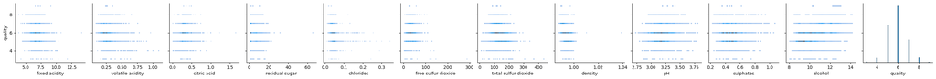

```python
sns.pairplot(data=whiteWine_df,y_vars='quality',kind='hist')
```

Looking at this histogram which showcase the chemical test based on the quality. One observation is the amount of alcohol seems to impact the quality of the wine.

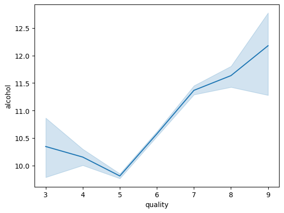

```python
sns.lineplot(data=whiteWine_df, x='quality', y='alcohol')
```

As you can see by this The amount of alcohol in the wine produces a better tasting white wine. Now lets look over red wine and seem if that is the same or maybe a different test is a better indicator.

[output not shown]

[output cut: 63 more lines]

[output not shown]

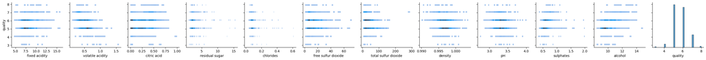

```python
sns.pairplot(data=redWine_df,y_vars='quality',kind='hist')
```

Once again the alcohol count seem to be an indicator for good quality wine.

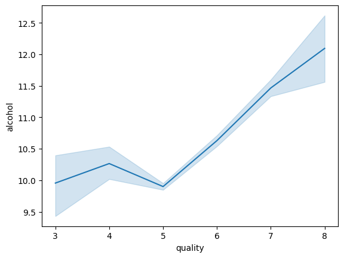

```python
sns.lineplot(data=redWine_df, x='quality', y='alcohol')
```

Just like the white wine, the higher amount of alocohol corresponds with good quality wine.

# Story time

Thank you for looking through this journey of fermented grap juice from the beautiful country of portugal. Known for ronaldo but also got some pretty good wine wheter it be red or white. Both histograms gave an indicator for alcohol being a massive contributor to the quality of wine. With that we took a deeper dive and zoomed in to the coorelation between alochol and the quality of both red and white wine and to my suprise we see positive correalation between the amount of alcohol and the quality of the wine itself.Did we answer out initial question though which was: What makes wines good or bad? I would say we did at least one part of making good or bad wine is the amount of alcohol it contains Im sure this is other factors but as Of now the more alcohol the better the wine was.

# The Impact

Well one big impact that noticed after doing the visualization is pointing out to people that more alochol makes better products which can easily do harm if people were to drink irresponsibly. As for data or perspectives that are missing one big one right of the bat would be the grapes that are used to make the wine. Another perspective could be if different people where to have revied the wines or the the evaluation points were different could have easily affected the data.

# Refrences

https://seaborn.pydata.org/generated/seaborn.pairplot.html - Figuring out how to only show the quality portion of the pairplot

https://www.kaggle.com/datasets/joebeachcapital/wine-quality - Dataset Link

(Exercise) Learning Pandas and Data Visualization - The import statements and more help with seaborn